# Ejercicio 2: tipologías de municipios (PCA + clustering)

SESIÓN 19 — APRENDIZAJE NO SUPERVISADO

Autor/a

Jorge Juvenal Campos Ferreira — TC2001B.601

Fecha de publicación

28 de mayo de 2026

```r
options(scipen = 999)
```

## Idea central

En el aprendizaje **NO supervisado** NO hay variable objetivo. **No** partimos en entrenamiento/prueba: no hay acierto que medir. El objetivo es **descubrir estructura**.

**Caso de política pública:** una secretaría de desarrollo tiene 400 municipios descritos por indicadores de urbanización, economía, educación, servicios y rezago. No existe una clasificación oficial previa. ¿Podemos agrupar los municipios en **tipologías** comparables para diseñar intervenciones diferenciadas? *(Datos ficticios, nombres genéricos.)*

Mismas técnicas y mismo ecosistema **tidymodels** que en el ejercicio anterior: `recipes::step_pca()` para el PCA y `tidyclust` para el clustering.

```r
library(tidyverse)
library(tidymodels)
library(tidyclust)
tidymodels_prefer()
```

## 1. Carga y exploración

```r
municipios <- read_csv("datos.csv")
glimpse(municipios)
```

```
Rows: 400
Columns: 13
$ municipio                <chr> "Municipio_039", "Municipio_045", "Municipio_…
$ pct_urbano               <dbl> 91.9, 75.0, 82.5, 93.5, 11.8, 54.8, 20.9, 0.0…
$ pct_ocupados_primario    <dbl> 22.0, 0.7, 0.7, 0.0, 51.3, 25.0, 42.6, 53.1, …
$ pct_ocupados_servicios   <dbl> 66.9, 75.6, 71.2, 74.4, 32.0, 69.8, 30.5, 37.…
$ densidad_pob_km2         <dbl> 1372.8, 1187.7, 1592.8, 1751.5, 5.0, 1128.9, …
$ pct_poblacion_indigena   <dbl> 0.0, 0.0, 8.4, 10.9, 30.7, 0.0, 29.6, 31.6, 1…
$ escolaridad_prom_anios   <dbl> 11.3, 12.2, 7.7, 11.1, 5.7, 11.9, 6.4, 7.1, 1…
$ pct_viviendas_internet   <dbl> 76.2, 72.5, 16.2, 81.6, 14.1, 71.0, 24.8, 25.…
$ pct_agua_entubada        <dbl> 100.0, 87.9, 65.0, 100.0, 68.6, 94.1, 62.0, 7…
$ tasa_mort_infantil       <dbl> 8.6, 7.3, 19.3, 9.9, 19.6, 5.8, 19.4, 23.3, 6…
$ pib_per_capita_mxn       <dbl> 222363, 230484, 108748, 267152, 44994, 200446…
$ gasto_pub_per_capita_mxn <dbl> 8419, 7117, 7494, 7876, 5639, 8124, 8486, 591…
$ indice_rezago_social     <dbl> -1.40, -0.96, 0.86, -1.22, 1.28, -1.14, 1.02,…
```

`municipio` es un **identificador** (nombre genérico): no es un indicador, se excluye. Revisamos NAs (PCA y distancias no los toleran):

```r
colSums(is.na(municipios))
```

```
               municipio               pct_urbano    pct_ocupados_primario
                       0                        0                        0
  pct_ocupados_servicios         densidad_pob_km2   pct_poblacion_indigena
                       0                        0                        0
  escolaridad_prom_anios   pct_viviendas_internet        pct_agua_entubada
                       0                        0                        0
      tasa_mort_infantil       pib_per_capita_mxn gasto_pub_per_capita_mxn
                       0                       16                        0
    indice_rezago_social
                       0
```

**Colinealidad.** `indice_rezago_social` se construyó a partir de escolaridad, conectividad y agua, así que está muy correlacionado con ellas. No lo eliminamos: el PCA lo absorbe.

```r
municipios %>%
  select(where(is.numeric)) %>%
  drop_na() %>%
  cor() %>%
  round(2) %>%
  .[c("escolaridad_prom_anios", "pct_viviendas_internet",
      "pct_agua_entubada"), "indice_rezago_social", drop = FALSE]
```

```
                       indice_rezago_social
escolaridad_prom_anios                -0.95
pct_viviendas_internet                -0.95
pct_agua_entubada                     -0.93
```

> **¿Por qué normalizar (z-score)?** Conviven porcentajes (0–100), años, tasas (por mil) y pesos (PIB en cientos de miles, densidad en miles). PCA y clustering son **sensibles a la escala**: sin normalizar, el PIB y la densidad dominarían las distancias y las tipologías reflejarían las **unidades**, no el perfil socioeconómico.

## 2. Receta de preprocesamiento

```r
receta <- recipe(~ ., data = municipios) %>%
  update_role(municipio, new_role = "id") %>%
  step_impute_median(all_numeric_predictors()) %>%
  step_normalize(all_numeric_predictors())

datos_norm <- receta %>% prep() %>% bake(new_data = NULL)
datos_norm %>%
  select(where(is.numeric)) %>%
  summarise(across(everything(), list(media = mean, desv = sd))) %>%
  glimpse()
```

```
Rows: 1
Columns: 24
$ pct_urbano_media               <dbl> 0.0000000000000005762057
$ pct_urbano_desv                <dbl> 1
$ pct_ocupados_primario_media    <dbl> -0.000000000000000199285
$ pct_ocupados_primario_desv     <dbl> 1
$ pct_ocupados_servicios_media   <dbl> -0.000000000000001712519
$ pct_ocupados_servicios_desv    <dbl> 1
$ densidad_pob_km2_media         <dbl> 0.0000000000000004601874
$ densidad_pob_km2_desv          <dbl> 1
$ pct_poblacion_indigena_media   <dbl> 0.0000000000000002625677
$ pct_poblacion_indigena_desv    <dbl> 1
$ escolaridad_prom_anios_media   <dbl> 0.0000000000000003277933
$ escolaridad_prom_anios_desv    <dbl> 1
$ pct_viviendas_internet_media   <dbl> 0.0000000000000005490053
$ pct_viviendas_internet_desv    <dbl> 1
$ pct_agua_entubada_media        <dbl> -0.000000000000006479262
$ pct_agua_entubada_desv         <dbl> 1
$ tasa_mort_infantil_media       <dbl> 0.0000000000000006378231
$ tasa_mort_infantil_desv        <dbl> 1
$ pib_per_capita_mxn_media       <dbl> 0.00000000000000009992007
$ pib_per_capita_mxn_desv        <dbl> 1
$ gasto_pub_per_capita_mxn_media <dbl> 0.0000000000000002416123
$ gasto_pub_per_capita_mxn_desv  <dbl> 1
$ indice_rezago_social_media     <dbl> -0.00000000000000002442491
$ indice_rezago_social_desv      <dbl> 1
```

## 3. PCA

```r
receta_pca <- recipe(~ ., data = municipios) %>%
  update_role(municipio, new_role = "id") %>%
  step_impute_median(all_numeric_predictors()) %>%
  step_normalize(all_numeric_predictors()) %>%
  step_pca(all_numeric_predictors(), num_comp = 11, id = "pca")

pca_prep <- prep(receta_pca)
```

### 3a. Varianza explicada (scree plot)

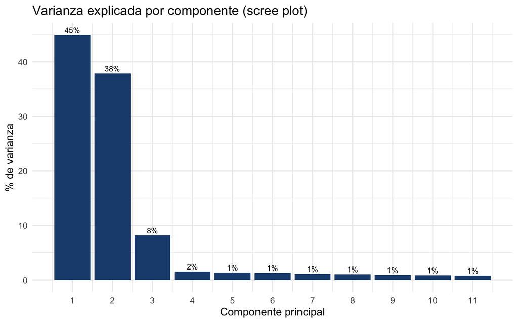

```r
varianza <- tidy(pca_prep, id = "pca", type = "variance") %>%
  filter(terms %in% c("percent variance", "cumulative percent variance")) %>%
  mutate(terms = recode(terms,
                        "percent variance" = "individual",
                        "cumulative percent variance" = "acumulada"))

varianza %>%
  filter(terms == "individual", component <= 11) %>%
  ggplot(aes(component, value)) +
  geom_col(fill = "#1e4c7d") +
  geom_text(aes(label = paste0(round(value), "%")), vjust = -0.4, size = 3) +
  scale_x_continuous(breaks = 1:11) +
  labs(title = "Varianza explicada por componente (scree plot)",
       x = "Componente principal", y = "% de varianza") +
  theme_minimal(base_size = 12)
```

### 3b. Cargas (loadings)

Estos datos tienen **dos ejes** casi independientes; las cargas lo revelan: uno suele ser **desarrollo** (escolaridad, internet, agua, PIB, rezago invertido) y otro **estructura económica** (servicios/urbano vs. primario/rural e indígena).

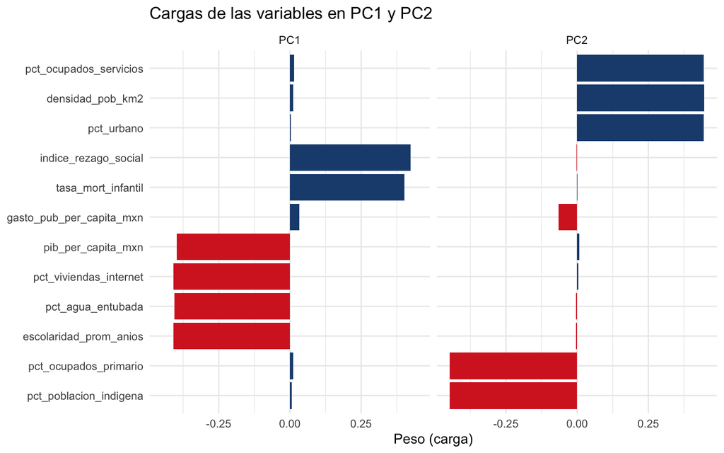

```r
cargas <- tidy(pca_prep, id = "pca", type = "coef") %>%
  filter(component %in% c("PC1", "PC2"))

cargas %>%
  mutate(terms = fct_reorder(terms, value)) %>%
  ggplot(aes(value, terms, fill = value > 0)) +
  geom_col(show.legend = FALSE) +
  facet_wrap(~ component) +
  scale_fill_manual(values = c(`TRUE` = "#1e4c7d", `FALSE` = "#d62828")) +
  labs(title = "Cargas de las variables en PC1 y PC2",
       x = "Peso (carga)", y = NULL) +
  theme_minimal(base_size = 11)
```

### 3c. Proyección en PC1-PC2

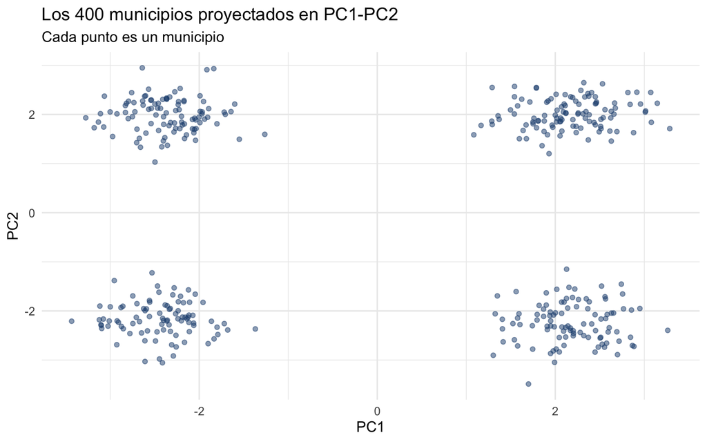

```r
scores <- bake(pca_prep, new_data = NULL) %>%
  rename(PC1 = PC01, PC2 = PC02)

scores %>%
  ggplot(aes(PC1, PC2)) +
  geom_point(alpha = 0.5, color = "#1e4c7d") +
  labs(title = "Los 400 municipios proyectados en PC1-PC2",
       subtitle = "Cada punto es un municipio") +
  theme_minimal(base_size = 12)
```

## 4. ¿Cuántas tipologías? Elección de k

`num_clusters = tune()` + `tune_cluster()` con dos diagnósticos: `sse_within_total` (codo) y `silhouette_avg` (más alta = mejor).

> **`nstart` importa.** k-means depende del arranque aleatorio de los centroides. Con un solo arranque (`nstart = 1`, el valor por defecto) puede caer en un óptimo local y confundir tipologías. Usamos `nstart = 25`.

```r
receta_clust <- recipe(~ ., data = municipios) %>%
  update_role(municipio, new_role = "id") %>%
  step_impute_median(all_numeric_predictors()) %>%
  step_normalize(all_numeric_predictors())

km_spec <- k_means(num_clusters = tune()) %>%
  set_engine("stats", nstart = 25)

wf_km <- workflow() %>% add_recipe(receta_clust) %>% add_model(km_spec)

metricas_clust <- cluster_metric_set(sse_within_total, silhouette_avg)
rejilla_k <- tibble(num_clusters = 1:8)
set.seed(123)
folds <- vfold_cv(municipios, v = 5)

set.seed(123)
afinado <- tune_cluster(wf_km, resamples = folds,
                        grid = rejilla_k, metrics = metricas_clust)
metricas_k <- collect_metrics(afinado)
metricas_k
```

```
# A tibble: 16 × 7
   num_clusters .metric          .estimator     mean     n   std_err .config
          <int> <chr>            <chr>         <dbl> <int>     <dbl> <chr>
 1            1 silhouette_avg   standard    NaN         0 NA        Preprocess…
 2            1 sse_within_total standard   3828         5  1.10e-12 Preprocess…
 3            2 silhouette_avg   standard      0.411     5  8.65e- 4 Preprocess…
 4            2 sse_within_total standard   2163.        5  2.92e+ 0 Preprocess…
 5            3 silhouette_avg   standard      0.447     5  2.38e- 3 Preprocess…
 6            3 sse_within_total standard   1408.        5  9.76e+ 0 Preprocess…
 7            4 silhouette_avg   standard      0.548     5  1.06e- 3 Preprocess…
 8            4 sse_within_total standard    749.        5  3.06e+ 0 Preprocess…
 9            5 silhouette_avg   standard      0.462     5  6.87e- 3 Preprocess…
10            5 sse_within_total standard    688.        5  4.05e+ 0 Preprocess…
11            6 silhouette_avg   standard      0.377     5  4.25e- 3 Preprocess…
12            6 sse_within_total standard    632.        5  4.83e+ 0 Preprocess…
13            7 silhouette_avg   standard      0.288     5  3.66e- 3 Preprocess…
14            7 sse_within_total standard    586.        5  4.81e+ 0 Preprocess…
15            8 silhouette_avg   standard      0.252     5  1.61e- 2 Preprocess…
16            8 sse_within_total standard    559.        5  7.93e+ 0 Preprocess…
```

**Método del codo:**

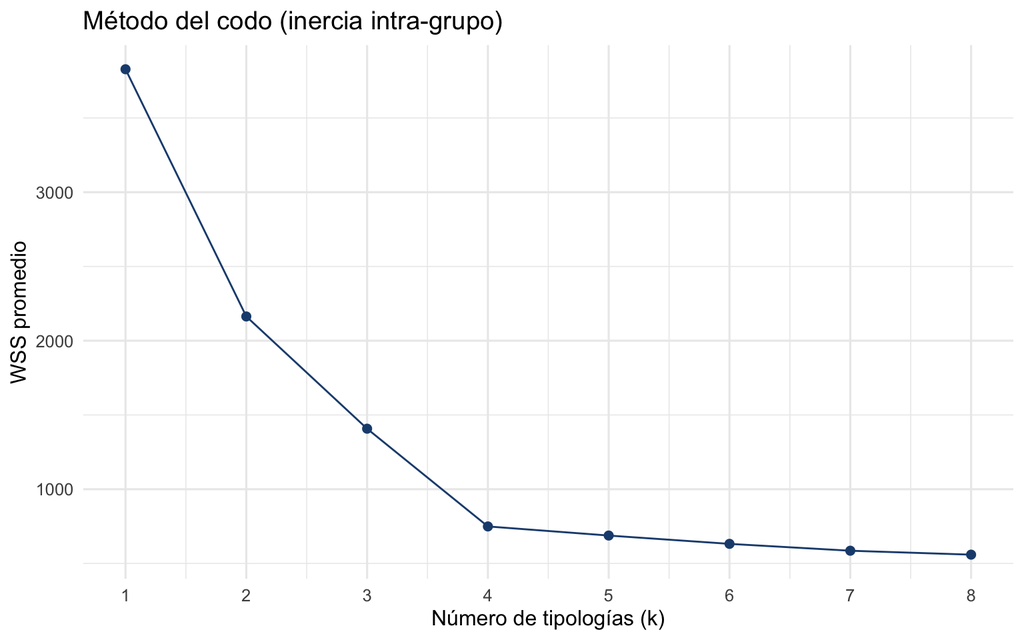

```r
metricas_k %>%
  filter(.metric == "sse_within_total") %>%
  ggplot(aes(num_clusters, mean)) +
  geom_line(color = "#1e4c7d") + geom_point(size = 2, color = "#1e4c7d") +
  scale_x_continuous(breaks = 1:8) +
  labs(title = "Método del codo (inercia intra-grupo)",
       x = "Número de tipologías (k)", y = "WSS promedio") +
  theme_minimal(base_size = 12)
```

**Método de la silueta:**

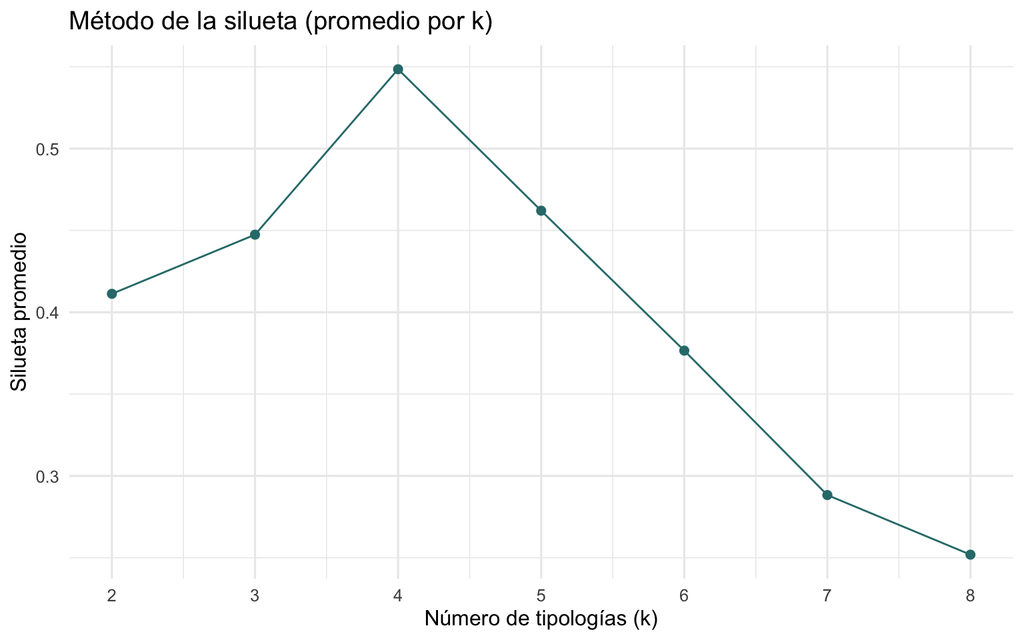

```r
metricas_k %>%
  filter(.metric == "silhouette_avg", num_clusters >= 2) %>%
  ggplot(aes(num_clusters, mean)) +
  geom_line(color = "#2d7a7a") + geom_point(size = 2, color = "#2d7a7a") +
  scale_x_continuous(breaks = 2:8) +
  labs(title = "Método de la silueta (promedio por k)",
       x = "Número de tipologías (k)", y = "Silueta promedio") +
  theme_minimal(base_size = 12)
```

> A diferencia del ejercicio de apostadores, aquí los diagnósticos **coinciden**: el codo se aplana en k = 4 y la silueta es máxima en k = 4. Cuando ambos apuntan al mismo valor, la elección es clara.

```r
k_elegido <- 4
```

## 5. K-means final

```r
km_final <- k_means(num_clusters = k_elegido) %>%
  set_engine("stats", nstart = 25)
wf_final <- workflow() %>% add_recipe(receta_clust) %>% add_model(km_final)

set.seed(123)
ajuste_km <- fit(wf_final, data = municipios)

asignacion <- extract_cluster_assignment(ajuste_km)
table(asignacion$.cluster)
```

```
Cluster_1 Cluster_2 Cluster_3 Cluster_4
      100       110       100        90
```

```r
extract_centroids(ajuste_km)
```

```
# A tibble: 4 × 13
  .cluster  pct_urbano pct_ocupados_primario pct_ocupados_servicios
  <fct>          <dbl>                 <dbl>                  <dbl>
1 Cluster_1      0.850                -0.925                  0.871
2 Cluster_2      0.924                -0.862                  0.894
3 Cluster_3     -1.02                  1.01                  -0.941
4 Cluster_4     -0.942                 0.954                 -1.01
# ℹ 9 more variables: densidad_pob_km2 <dbl>, pct_poblacion_indigena <dbl>,
#   escolaridad_prom_anios <dbl>, pct_viviendas_internet <dbl>,
#   pct_agua_entubada <dbl>, tasa_mort_infantil <dbl>,
#   pib_per_capita_mxn <dbl>, gasto_pub_per_capita_mxn <dbl>,
#   indice_rezago_social <dbl>
```

### 5a. Las tipologías sobre PC1-PC2

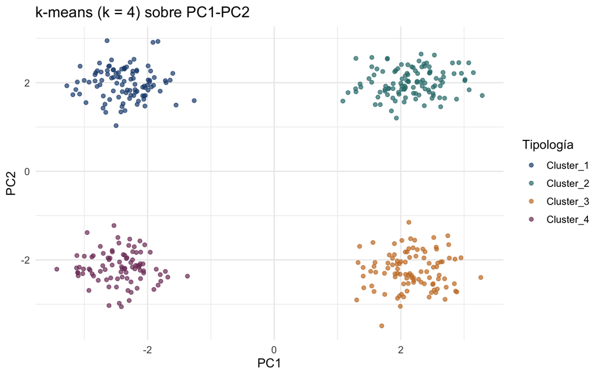

```r
scores_grupos <- scores %>% bind_cols(cluster = asignacion$.cluster)

scores_grupos %>%
  ggplot(aes(PC1, PC2, color = cluster)) +
  geom_point(alpha = 0.7) +
  scale_color_manual(values = c("#1e4c7d", "#2d7a7a", "#c97b2a", "#7d3c66")) +
  labs(title = paste0("k-means (k = ", k_elegido, ") sobre PC1-PC2"),
       color = "Tipología") +
  theme_minimal(base_size = 12)
```

### 5b. Perfilado en unidades originales

```r
municipios_grupos <- municipios %>% bind_cols(cluster = asignacion$.cluster)

perfil <- municipios_grupos %>%
  group_by(cluster) %>%
  summarise(
    n = n(),
    pct_urbano = mean(pct_urbano),
    escolaridad_prom_anios = mean(escolaridad_prom_anios),
    pct_viviendas_internet = mean(pct_viviendas_internet),
    pct_ocupados_primario = mean(pct_ocupados_primario),
    pct_poblacion_indigena = mean(pct_poblacion_indigena),
    tasa_mort_infantil = mean(tasa_mort_infantil),
    pib_per_capita_mxn = mean(pib_per_capita_mxn, na.rm = TRUE),
    indice_rezago_social = mean(indice_rezago_social)
  ) %>%
  mutate(across(where(is.numeric), ~ round(.x, 1)))
perfil
```

```
# A tibble: 4 × 10
  cluster       n pct_urbano escolaridad_prom_anios pct_viviendas_internet
  <fct>     <dbl>      <dbl>                  <dbl>                  <dbl>
1 Cluster_1   100       83.3                   11.2                   74.7
2 Cluster_2   110       85.6                    6.7                   21.9
3 Cluster_3   100       24.1                    6.7                   20.8
4 Cluster_4    90       26.6                   11.3                   75.2
# ℹ 5 more variables: pct_ocupados_primario <dbl>,
#   pct_poblacion_indigena <dbl>, tasa_mort_infantil <dbl>,
#   pib_per_capita_mxn <dbl>, indice_rezago_social <dbl>
```

**Interpretación.** Las tipologías cruzan dos ejes (desarrollo × estructura económica): *urbano desarrollado* (servicios, desarrollo alto), *agroindustrial próspero* (desarrollo alto pero sector primario), *urbano popular* (urbano/servicios pero desarrollo bajo) y *rural marginado* (primario, baja escolaridad, mortalidad y rezago altos → prioridad). Cada tipología pide una política distinta.

## 6. Clustering jerárquico (comparación)

```r
hc_spec <- hier_clust(num_clusters = k_elegido,
                      linkage_method = "ward.D2") %>%
  set_engine("stats")

wf_hc <- workflow() %>% add_recipe(receta_clust) %>% add_model(hc_spec)
ajuste_hc <- fit(wf_hc, data = municipios)
asignacion_hc <- extract_cluster_assignment(ajuste_hc)

table(kmeans = asignacion$.cluster, jerarquico = asignacion_hc$.cluster)
```

```
           jerarquico
kmeans      Cluster_1 Cluster_2 Cluster_3 Cluster_4
  Cluster_1       100         0         0         0
  Cluster_2         0       110         0         0
  Cluster_3         0         0       100         0
  Cluster_4         0         0         0        90
```

Las etiquetas son **arbitrarias**: no miramos la diagonal, sino si cada grupo de un método cae mayormente en **un solo** grupo del otro. Aquí la correspondencia es casi perfecta: ambos métodos descubren las **mismas cuatro tipologías**, lo que da mucha confianza en el resultado.